# Reproducible Research: Peer Assessment 1

Author: Vergara, Enrico Marco

Date: May 1, 2019

## ——————————————————————————————

## INTRODUCTION

As part of the completion for Reproducible Research Course, this course project entitled “Reproducible Research: Peer Assessment 1” aims to demonstrate the creation of an R Markdown document which reflects literate programming using markdown and R Programming environment. This assignment is described in multiple parts. A written report that answers the required questions is to be provided.

## ——————————————————————————————

## DATA SET

This assignment makes use of data from a personal activity monitoring device. This device collects data at 5 minute intervals through out the day. The data consists of two months of data from an anonymous individual collected during the months of October and November, 2012 and include the number of steps taken in 5 minute intervals each day. The dataset is stored in a comma-separated-value (CSV) file and there are a total of 17,568 observations in this dataset.

## ——————————————————————————————

## A. Loading and Preprocessing the Data

```r
URL <- "https://d396qusza40orc.cloudfront.net/repdata%2Fdata%2Factivity.zip"
Dataset <- "activity.zip"
if (!file.exists(Dataset)){
  download.file(URL, destfile = Dataset, mode='wb')
}
if (!file.exists(Dataset)){
  unzip(Dataset)
}

activity <- read.csv("activity.csv", sep = ",", colClasses = c("numeric", "Date", "numeric"))
```

Let us now look unto some of the pertinent details about our data.

```r
dim(activity)
```

```
## [1] 17568     3
```

```r
names(activity)
```

```
## [1] "steps"    "date"     "interval"
```

```r
head(activity[which(!is.na(activity$steps)), ]) # Data without NAs
```

```
##     steps       date interval
## 289     0 2012-10-02        0
## 290     0 2012-10-02        5
## 291     0 2012-10-02       10
## 292     0 2012-10-02       15
## 293     0 2012-10-02       20
## 294     0 2012-10-02       25
```

```r
str(activity)
```

```
## 'data.frame':    17568 obs. of  3 variables:
##  $ steps   : num  NA NA NA NA NA NA NA NA NA NA ...
##  $ date    : Date, format: "2012-10-01" "2012-10-01" ...
##  $ interval: num  0 5 10 15 20 25 30 35 40 45 ...
```

## ——————————————————————————————

## B. What is mean total number of steps taken per day?

In order to calulate for the mean total number of steps taken per day, the total number of steps taken per day are firstly identified. (NOTE: For this part, the missing values in the data set are ignored.)

```r
TotalStepsPerDay <- aggregate(x = activity$steps, by = list(activity$date), FUN = sum)
names(TotalStepsPerDay) <- c("Date", "TotalSteps")
head(TotalStepsPerDay)
```

```
##         Date TotalSteps
## 1 2012-10-01         NA
## 2 2012-10-02        126
## 3 2012-10-03      11352
## 4 2012-10-04      12116
## 5 2012-10-05      13294
## 6 2012-10-06      15420
```

A useful to tool in order to see the data in a bigger picture is to use exploratory plots. This way, trends, potential patterns and discrepancies are easily determined. For the sample data, here is a histogram showing the frequency of total steps taken each day.

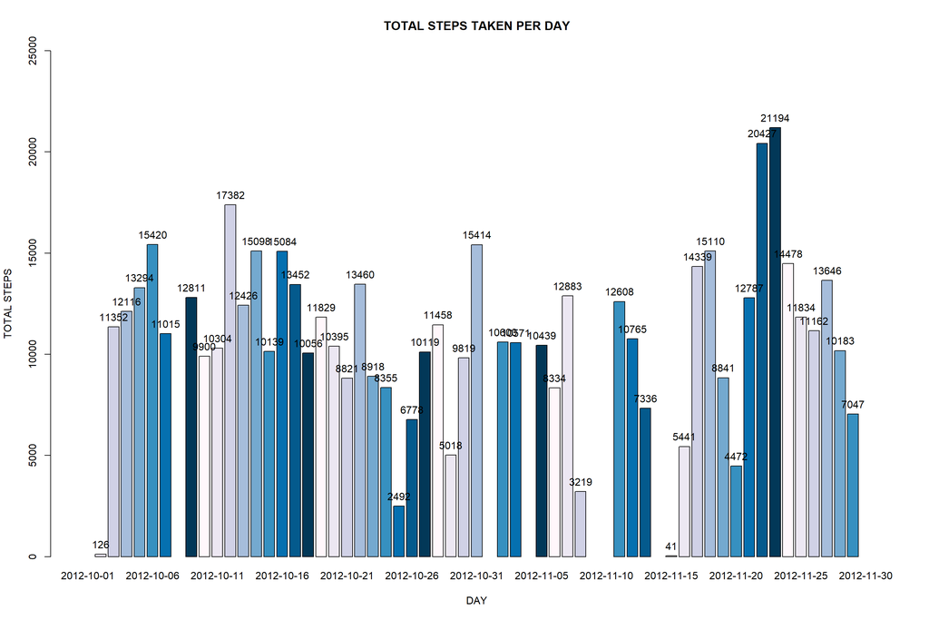

```r
library(RColorBrewer)
Color1 <-  brewer.pal(9, "PuBu")
Plot1 <- barplot(height=TotalStepsPerDay$TotalSteps,
                 names.arg=TotalStepsPerDay$Date,
                 col = Color1, ylim = c(0,25000),
                 xlab="DAY",
                 ylab = "TOTAL STEPS",
                 main = "TOTAL STEPS TAKEN PER DAY")
text(Plot1, TotalStepsPerDay$TotalSteps,
     labels = TotalStepsPerDay$TotalSteps,
     pos = 3)
```

```r
Date <- data.frame(TotalStepsPerDay$Date)
Steps1 <- aggregate(x = activity$steps, by = list(activity$date), FUN = mean, na.rm=TRUE)
Steps2 <- aggregate(x = activity$steps, by = list(activity$date), FUN = median, na.rm=TRUE)
Steps <- cbind(Date, Steps1[,2], Steps2[,2])
names(Steps) <- c("Date", "Mean", "Median")
print(Steps,type="html")
```

```
##          Date       Mean Median
## 1  2012-10-01        NaN     NA
## 2  2012-10-02  0.4375000      0
## 3  2012-10-03 39.4166667      0
## 4  2012-10-04 42.0694444      0
## 5  2012-10-05 46.1597222      0
## 6  2012-10-06 53.5416667      0
## 7  2012-10-07 38.2465278      0
## 8  2012-10-08        NaN     NA
## 9  2012-10-09 44.4826389      0
## 10 2012-10-10 34.3750000      0
## 11 2012-10-11 35.7777778      0
## 12 2012-10-12 60.3541667      0
## 13 2012-10-13 43.1458333      0
## 14 2012-10-14 52.4236111      0
```

[output cut: 47 more lines]

## ——————————————————————————————

## C. What is the average daily activity pattern?

This time, in order to view the average daily activity pattern, another exploratory graph, time series, will be used. A time series table shows a sequence of numerical data points in successive order. Thus, the 5-minute interval and average number of steps taken averaged across all days will be plotted.

```r
MeanStepsPerInteval <- aggregate(x = activity$steps, by = list(activity$interval), FUN = mean, na.rm=TRUE)
names(MeanStepsPerInteval) <- c("Interval", "MeanSteps")
head(MeanStepsPerInteval)
```

```
##   Interval MeanSteps
## 1        0 1.7169811
## 2        5 0.3396226
## 3       10 0.1320755
## 4       15 0.1509434
## 5       20 0.0754717
## 6       25 2.0943396
```

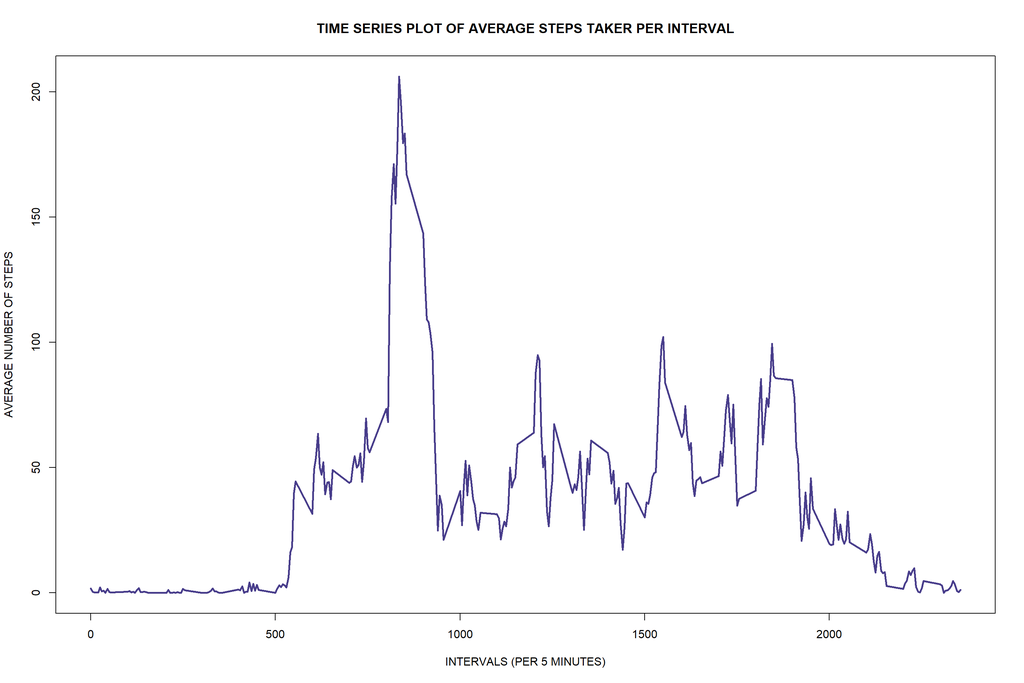

```r
Plot2 <- plot(x = MeanStepsPerInteval$Interval,
              y = MeanStepsPerInteval$MeanSteps,
              type = "l", col="darkslateblue", lwd=2.5,
              main="TIME SERIES PLOT OF AVERAGE STEPS TAKER PER INTERVAL",
              ylab="AVERAGE NUMBER OF STEPS", xlab="INTERVALS (PER 5 MINUTES)")
```

Looking unto the data, to answer which 5-minute interval, on average across all the days in the dataset, contains the maximum number of steps, the following are made.

```r
AverageMaxSteps <- max(MeanStepsPerInteval$MeanSteps)
MaxStepsInterval <- MeanStepsPerInteval$Interval[which.max(MeanStepsPerInteval$MeanSteps)]
AverageMaxSteps
```

```
## [1] 206.1698
```

```r
MaxStepsInterval
```

```
## [1] 835
```

Thus, the 5-minute interval, on average across all the days in the dataset, which contains the maximum number of steps is **835** with **206.1698** total of steps on average.

## ——————————————————————————————

## D. Imputing Missing Values

In order to confirm if there are missing values in the data.  
Is it true that there are missing values in the data?

```r
anyNA(activity)
```

```
## [1] TRUE
```

Now, it is time to look at each of the variable to grasp which of them is populated with missing values.

```r
NAValues <- data.frame(step=sum(is.na(activity$steps)),
                       date=sum(is.na(activity$date)),
                       interval=sum(is.na(activity$interval)))
NAValues
```

```
##   step date interval
## 1 2304    0        0
```

It is very evident that the “steps” variable has all the missing values with a total of **2304**. In order to solve this problem, an imputing strategy is to be deviced. There are lots of ways to deal with missing data in R and for this problem, “Mean/ Mode/ Median Imputation” strategy is to be used.  
To make the imputation possible, a loop is to be used in order to forced the missing values to be relaced with the corresponding mean that was calculated on the previous question.

```r
ImputeActivity <- activity
for(x in 1:nrow(activity)) {
  if(is.na(ImputeActivity[x, 1])==TRUE) {
    ImputeActivity[x, 1] <- MeanStepsPerInteval[MeanStepsPerInteval$Interval %in%
                                                  ImputeActivity[x, 3], 2]
  }
}
head(ImputeActivity)
```

```
##       steps       date interval
## 1 1.7169811 2012-10-01        0
## 2 0.3396226 2012-10-01        5
## 3 0.1320755 2012-10-01       10
## 4 0.1509434 2012-10-01       15
## 5 0.0754717 2012-10-01       20
## 6 2.0943396 2012-10-01       25
```

Now to confirm if all the missing values in the data are replaced in the new data set.  
Is it true that there are still missing values in the data in the new data set?

```r
anyNA(ImputeActivity)
```

```
## [1] FALSE
```

Since it is false, it is then confirmed that there are now no missing values on the new data set. However to really confirm, here is the summary per variable.

```r
NAValues2 <- data.frame(step=sum(is.na(ImputeActivity$steps)),
                       date=sum(is.na(ImputeActivity$date)),
                       interval=sum(is.na(ImputeActivity$interval)))
NAValues2
```

```
##   step date interval
## 1    0    0        0
```

```r
TotalStepsPerDay2 <- aggregate(x = ImputeActivity$steps, by = list(ImputeActivity$date), FUN = sum)
names(TotalStepsPerDay2) <- c("Date", "TotalSteps")
head(TotalStepsPerDay2)
```

```
##         Date TotalSteps
## 1 2012-10-01   10766.19
## 2 2012-10-02     126.00
## 3 2012-10-03   11352.00
## 4 2012-10-04   12116.00
## 5 2012-10-05   13294.00
## 6 2012-10-06   15420.00
```

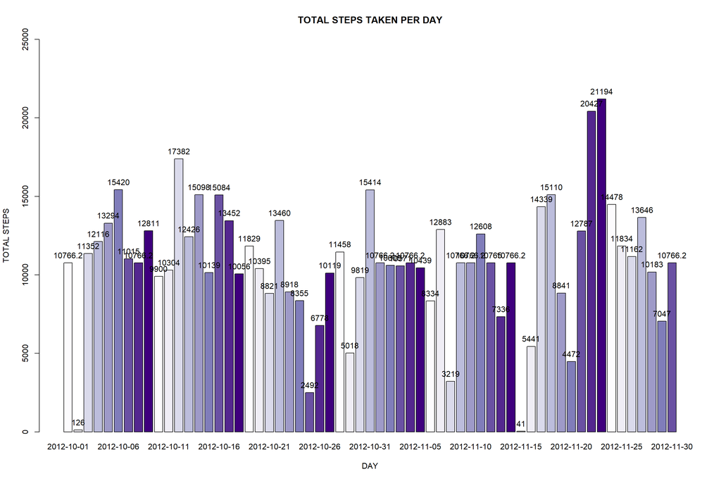

```r
library(RColorBrewer)
Color2 <-  brewer.pal(9, "Purples")
Plot3 <- barplot(height=TotalStepsPerDay2$TotalSteps,
                 names.arg=TotalStepsPerDay2$Date,
                 col = Color2, ylim = c(0,25000),
                 xlab="DAY",
                 ylab = "TOTAL STEPS",
                 main = "TOTAL STEPS TAKEN PER DAY")
text(Plot3, TotalStepsPerDay2$TotalSteps,
     labels = round(TotalStepsPerDay2$TotalSteps, digits = 1),
     pos = 3)
```

A big difference to the graph on the first part of this assignment can be seen for the latter has complete data. Here is the calculated mean and median per day,

```r
Date2 <- data.frame(TotalStepsPerDay2$Date)
Steps3 <- aggregate(x = ImputeActivity$steps, by = list(ImputeActivity$date), FUN = mean, na.rm=TRUE)
Steps4 <- aggregate(x = ImputeActivity$steps, by = list(ImputeActivity$date), FUN = median, na.rm=TRUE)
Steps5 <- cbind(Date2, Steps3[,2], Steps4[,2])
names(Steps5) <- c("Date", "Mean", "Median")
print(Steps5,type="html")
```

```
##          Date       Mean   Median
## 1  2012-10-01 37.3825996 34.11321
## 2  2012-10-02  0.4375000  0.00000
## 3  2012-10-03 39.4166667  0.00000
## 4  2012-10-04 42.0694444  0.00000
## 5  2012-10-05 46.1597222  0.00000
## 6  2012-10-06 53.5416667  0.00000
## 7  2012-10-07 38.2465278  0.00000
## 8  2012-10-08 37.3825996 34.11321
## 9  2012-10-09 44.4826389  0.00000
## 10 2012-10-10 34.3750000  0.00000
## 11 2012-10-11 35.7777778  0.00000
## 12 2012-10-12 60.3541667  0.00000
## 13 2012-10-13 43.1458333  0.00000
## 14 2012-10-14 52.4236111  0.00000
```

[output cut: 47 more lines]

Using the imputation strategy made, a big difference now can be seen from the histogram and table above. Firstly, it is now not populated by missing values. From the initial data set where missing values are existing, the histogram shows missing measurements (8 days) where there are no recordings. On the other hand, it rises to a certain value when the imputation was done. Same with the table, where calculations can’t be done with existing missing values, now numerical values are observed and more useful.

## ——————————————————————————————

## E. Are there differences in activity patterns between weekdays and weekends?

To answer the question, it is needed first to identify the days of the week of the given date. The next step is to categorize if it falls on a weekend or a weekday. The following line of codes will give the desired factors for the date.

```r
ImputeActivity2 <- ImputeActivity
ImputeActivity2$day <-weekdays(ImputeActivity2$date)
ImputeActivity2$typeofday <- ifelse (ImputeActivity2$day != "Saturday" & ImputeActivity2$day != "Sunday", "Weekday", "Weekend")
head(ImputeActivity2)
```

```
##       steps       date interval    day typeofday
## 1 1.7169811 2012-10-01        0 Monday   Weekday
## 2 0.3396226 2012-10-01        5 Monday   Weekday
## 3 0.1320755 2012-10-01       10 Monday   Weekday
## 4 0.1509434 2012-10-01       15 Monday   Weekday
## 5 0.0754717 2012-10-01       20 Monday   Weekday
## 6 2.0943396 2012-10-01       25 Monday   Weekday
```

To generate the a panel plot containing a time series plo of the 5-minute interval and the average number of steps taken, averaged across all weekday days or weekend days for the understanding of the patterns between weekdays and weekends, here is the comparison.

```r
Weekday <- subset(ImputeActivity2, ImputeActivity2$typeofday == "Weekday")
Weekend <- subset(ImputeActivity2, ImputeActivity2$typeofday == "Weekend")
MeanStepsPerInteval_Weekday <- aggregate(x = Weekday$steps, by = list(Weekday$interval), FUN = mean)
MeanStepsPerInteval_Weekend <- aggregate(x = Weekend$steps, by = list(Weekend$interval), FUN = mean)
names(MeanStepsPerInteval_Weekday) <- c("Interval", "MeanSteps")
MeanStepsPerInteval_Weekday$Type <- "Weekday"
names(MeanStepsPerInteval_Weekend) <- c("Interval", "MeanSteps")
MeanStepsPerInteval_Weekend$Type <- "Weekend"
head(MeanStepsPerInteval_Weekday)
```

```
##   Interval  MeanSteps    Type
## 1        0 2.25115304 Weekday
## 2        5 0.44528302 Weekday
## 3       10 0.17316562 Weekday
## 4       15 0.19790356 Weekday
## 5       20 0.09895178 Weekday
## 6       25 1.59035639 Weekday
```

```r
head(MeanStepsPerInteval_Weekend)
```

```
##   Interval   MeanSteps    Type
## 1        0 0.214622642 Weekend
## 2        5 0.042452830 Weekend
## 3       10 0.016509434 Weekend
## 4       15 0.018867925 Weekend
## 5       20 0.009433962 Weekend
## 6       25 3.511792453 Weekend
```

Time Series:

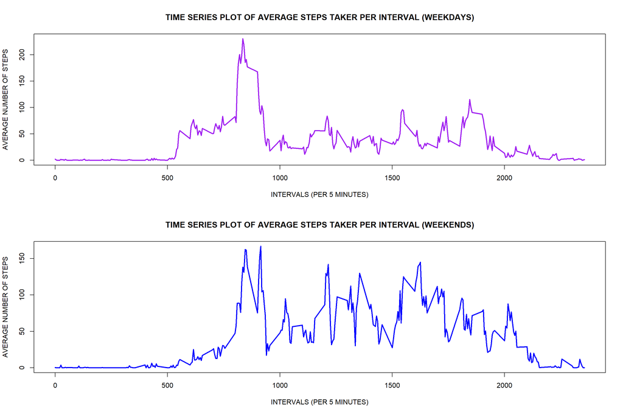

```r
par(mfrow=c(2, 1))
plot(x = MeanStepsPerInteval_Weekday$Interval,
              y = MeanStepsPerInteval_Weekday$MeanSteps,
              type = "l", col="purple", lwd=2.5,
              main="TIME SERIES PLOT OF AVERAGE STEPS TAKER PER INTERVAL (WEEKDAYS)",
              ylab="AVERAGE NUMBER OF STEPS", xlab="INTERVALS (PER 5 MINUTES)")
plot(x = MeanStepsPerInteval_Weekend$Interval,
              y = MeanStepsPerInteval_Weekend$MeanSteps,
              type = "l", col="blue", lwd=2.5,
              main="TIME SERIES PLOT OF AVERAGE STEPS TAKER PER INTERVAL (WEEKENDS)",
              ylab="AVERAGE NUMBER OF STEPS", xlab="INTERVALS (PER 5 MINUTES)")
```